# Research guide: county-year frame

New public-charity registrations

| ROWS | DISTINCT | ZERO |
| --- | --- | --- |
| 78,600 | 642 (0.8%) | 12,545 (16.0%) |

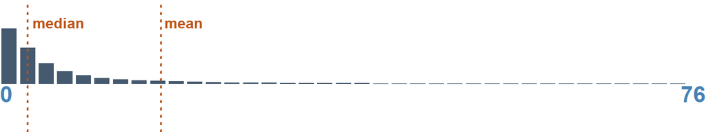

**PREVIEW**:

```
0 · 1 · 2 · 3 · 4 · 5 · 6 · 7 · 8 · 9 · 10 · 11 · 12 · 13 · 14 · 15 · 16 · 17 · 18 · 19 · 21
20 · 22 · 23 · 24 · 26 · 25 · 27 · 29 · 28 · 30 · 31 · 32 · 34 · 33 · 35 · 36 · 38 · 37 · 39
```

**STATS**:

| MIN | Q05 | Q25 | Q50 | MEAN | Q75 | Q95 | MAX |
| --- | --- | --- | --- | --- | --- | --- | --- |
| 0 | 0 | 1 | 3 | 17.34 | 10 | 74 | 2,898 |

number

New public-charity registrations excluding hospitals and universities

`n_entry_c3pc_nohu`

New public-charity registrations excluding hospitals and universities

| ROWS | DISTINCT | ZERO |
| --- | --- | --- |
| 78,600 | 646 (0.8%) | 12,637 (16.1%) |

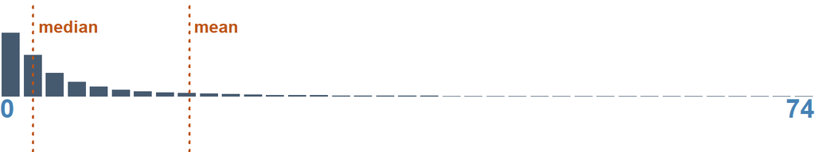

**PREVIEW**:

```
0 · 1 · 2 · 3 · 4 · 5 · 6 · 7 · 8 · 9 · 10 · 11 · 12 · 13 · 14 · 15 · 16 · 17 · 18 · 19 · 21
20 · 23 · 22 · 24 · 26 · 25 · 27 · 29 · 28 · 31 · 30 · 32 · 33 · 34 · 35 · 37 · 36 · 38 · 40
```

**STATS**:

| MIN | Q05 | Q25 | Q50 | MEAN | Q75 | Q95 | MAX |
| --- | --- | --- | --- | --- | --- | --- | --- |
| 0 | 0 | 1 | 3 | 17.24 | 10 | 73 | 2,891 |

number

New private-foundation registrations

`n_entry_pf`

| ROWS | DISTINCT | ZERO |
| --- | --- | --- |
| 78,600 | 145 (0.2%) | 62,184 (79.1%) |

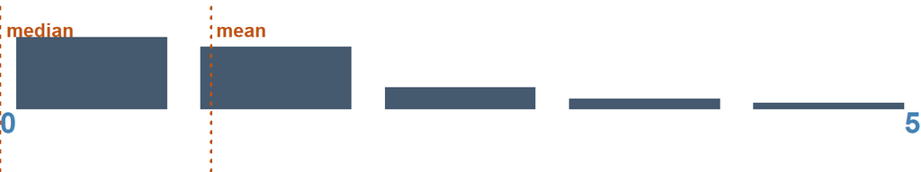

**PREVIEW**:

```
0 · 1 · 2 · 3 · 4 · 5 · 6 · 7 · 8 · 10 · 9 · 11 · 12 · 13 · 14 · 16 · 15 · 19 · 17 · 18 · 20
21 · 22 · 23 · 24 · 29 · 34 · 30 · 26 · 25 · 27 · 28 · 31 · 33 · 36 · 35 · 47 · 37 · 38 · 39
```

**STATS**:

| MIN | Q05 | Q25 | Q50 | MEAN | Q75 | Q95 | MAX |
| --- | --- | --- | --- | --- | --- | --- | --- |
| 0 | 0 | 0 | 0 | 1.15 | 0 | 4 | 377 |

number

Population 25+

`edu_den`

Population 25+

| ROWS | DISTINCT | MISSING/NA |
| --- | --- | --- |
| 78,600 | 34,961 (44.5%) | 28,313 (36.0%) |

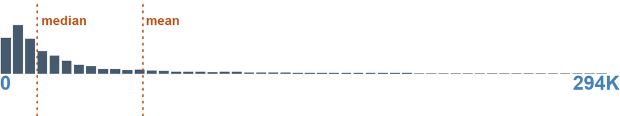

**PREVIEW**:

```
3748 · 4716 · 13640 · 1339 · 1579 · 1661 · 1760 · 2675 · 2849 · 4054 · 4243 · 4686 · 5193 · 5340
5459 · 5528 · 5766 · 5790 · 6456 · 7265 · 9527 · 12033 · 670 · 1305 · 1311 · 1634 · 1753 · 1773
```

**STATS**:

| MIN | Q05 | Q25 | Q50 | MEAN | Q75 | Q95 | MAX |
| --- | --- | --- | --- | --- | --- | --- | --- |
| 31 | 1,939 | 7,537 | 17,639 | 67,974.55 | 45,480.5 | 290,636.9 | 6,922,061 |

number

Population 25+ with BA or higher

`edu_ba_num`

Population 25+ with BA or higher

| ROWS | DISTINCT | MISSING/NA | ZERO |
| --- | --- | --- | --- |
| 78,600 | 19,805 (25.2%) | 28,313 (36.0%) | 7 (0.0%) |

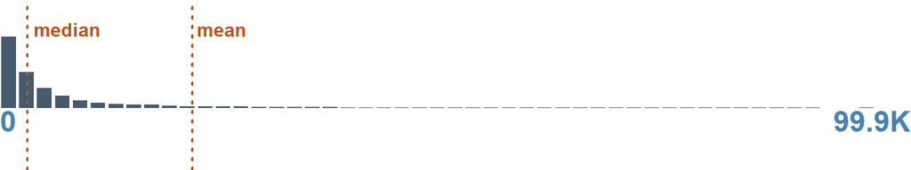

**PREVIEW**:

```
903 · 456 · 457 · 855 · 674 · 862 · 868 · 1113 · 444 · 445 · 729 · 892 · 939 · 1087 · 228 · 311
436 · 527 · 609 · 726 · 731 · 762 · 881 · 891 · 954 · 1222 · 1226 · 356 · 415 · 440 · 460 · 463
```

**STATS**:

| MIN | Q05 | Q25 | Q50 | MEAN | Q75 | Q95 | MAX |
| --- | --- | --- | --- | --- | --- | --- | --- |
| 0 | 350 | 1,158 | 3,035 | 21,074.72 | 9,975 | 98,353.2 | 2,491,166 |

number

Foreign-born population

`fb_num`

Foreign-born population

| ROWS | DISTINCT | MISSING/NA | ZERO |
| --- | --- | --- | --- |
| 78,600 | 12,556 (16.0%) | 28,313 (36.0%) | 217 (0.3%) |

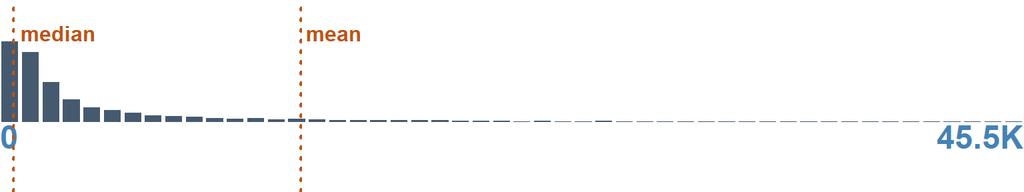

**PREVIEW**:

```
0 · 56 · 31 · 47 · 30 · 22 · 13 · 25 · 26 · 17 · 38 · 83 · 57 · 92 · 37 · 44 · 78 · 27 · 39 · 14
50 · 21 · 24 · 34 · 54 · 65 · 15 · 23 · 32 · 55 · 58 · 59 · 20 · 11 · 93 · 12 · 80 · 40 · 49
```

**STATS**:

| MIN | Q05 | Q25 | Q50 | MEAN | Q75 | Q95 | MAX |
| --- | --- | --- | --- | --- | --- | --- | --- |
| 0 | 28 | 175 | 614 | 13,371.95 | 2,748 | 45,515.5 | 3,485,724 |

number

Total population

`fb_den`

Total population (place of birth universe)

| ROWS | DISTINCT | MISSING/NA |
| --- | --- | --- |
| 78,600 | 38,496 (49.0%) | 28,313 (36.0%) |

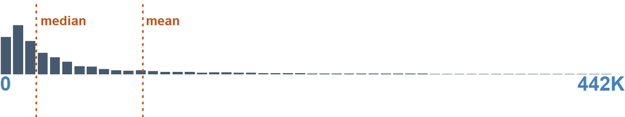

**PREVIEW**:

```
3389 · 8249 · 7039 · 564 · 1865 · 2029 · 2292 · 2502 · 3058 · 3311 · 4061 · 4318 · 4373 · 4686
5071 · 5498 · 5877 · 5974 · 5982 · 6495 · 6926 · 7678 · 8286 · 8394 · 8673 · 9000 · 9127 · 9302
```

**STATS**:

| MIN | Q05 | Q25 | Q50 | MEAN | Q75 | Q95 | MAX |
| --- | --- | --- | --- | --- | --- | --- | --- |
| 33 | 2,805.9 | 10,979 | 25,725 | 101,122.2 | 67,197 | 435,859.1 | 10,105,722 |

number · ratio

Household income Gini index

`gini`

Household income Gini index. Gap-filled: interpolated between observed years; see also gini_obs, _lin and _locf.

| ROWS | DISTINCT | MISSING/NA |
| --- | --- | --- |
| 78,600 | 33,765 (43.0%) | 80 (0.1%) |

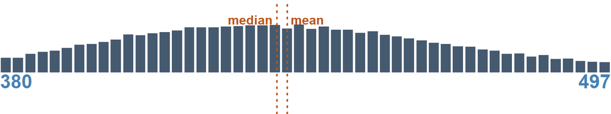

**PREVIEW**:

```
0.437 · 0.433 · 0.442 · 0.432 · 0.423 · 0.419 · 0.43 · 0.424 · 0.436 · 0.438 · 0.434 · 0.439
0.426 · 0.452 · 0.422 · 0.428 · 0.429 · 0.443 · 0.415 · 0.42 · 0.427 · 0.444 · 0.425 · 0.435
```

**STATS**:

| MIN | Q05 | Q25 | Q50 | MEAN | Q75 | Q95 | MAX |
| --- | --- | --- | --- | --- | --- | --- | --- |
| 0.08 | 0.38 | 0.41 | 0.43 | 0.43 | 0.46 | 0.5 | 0.73 |

number

Share 25+ with BA+

`pct_ba`

Share 25+ with BA+. Gap-filled: interpolated between observed years; see also pct_ba_obs, _lin and _locf.

| ROWS | DISTINCT | MISSING/NA | ZERO |
| --- | --- | --- | --- |
| 78,600 | 78,166 (99.4%) | 80 (0.1%) | 7 (0.0%) |

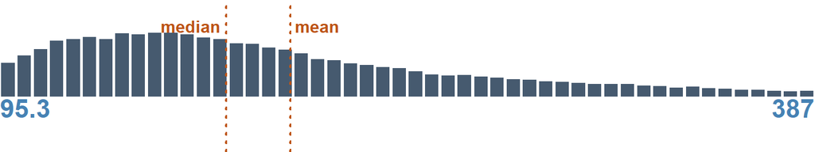

**PREVIEW**:

```
0.2 · 0 · 0.143 · 0.167 · 0.25 · 0.111 · 0.125 · 0.214 · 0.105 · 0.161 · 0.169 · 0.207 · 0.222
0.231 · 0.267 · 0.333 · 0.12 · 0.127 · 0.136 · 0.147 · 0.152 · 0.156 · 0.158
```

**STATS**:

| MIN | Q05 | Q25 | Q50 | MEAN | Q75 | Q95 | MAX |
| --- | --- | --- | --- | --- | --- | --- | --- |
| 0 | 0.1 | 0.14 | 0.18 | 0.2 | 0.24 | 0.39 | 0.81 |

number · measurement

Foreign-born share

`pct_foreign_born`

Foreign-born share. Gap-filled: interpolated between observed years; see also pct_foreign_born_obs, _lin and _locf.

| ROWS | DISTINCT | MISSING/NA | ZERO |
| --- | --- | --- | --- |
| 78,600 | 77,817 (99.0%) | 80 (0.1%) | 226 (0.3%) |

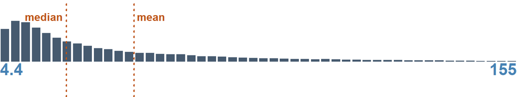

**PREVIEW**:

```
0 · 0.006 · 0.009 · 0.01 · 0.013 · 0.014 · 0.016 · 0.017 · 0.018 · 0.02 · 0.026 · 0.03 · 0.04
0.002 · 0.004 · 0.005 · 0.007
```

**STATS**:

| MIN | Q05 | Q25 | Q50 | MEAN | Q75 | Q95 | MAX |
| --- | --- | --- | --- | --- | --- | --- | --- |
| 0 | 0 | 0.01 | 0.02 | 0.04 | 0.05 | 0.16 | 0.72 |

number · measurement

Personal income

`personal_income`

Personal income

| ROWS | DISTINCT | MISSING/NA |
| --- | --- | --- |
| 78,600 | 77,573 (98.7%) | 2 (0.0%) |

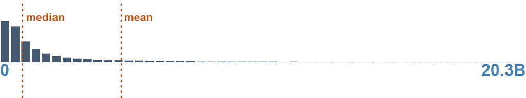

**PREVIEW**:

```
75231000 · 93559000 · 149092000 · 191161000 · 202541000 · 239926000 · 242289000 · 258571000
276975000 · 295586000 · 338258000 · 430141000 · 483594000 · 524342000 · 531986000 · 564174000
```

**STATS**:

| MIN | Q05 | Q25 | Q50 | MEAN | Q75 | Q95 | MAX |
| --- | --- | --- | --- | --- | --- | --- | --- |
| 1,899,000 | 103,179,250 | 359,512,500 | 870,675,500 | 4,690,523,665 | 2,495,182,250 | 20,004,464,050 | 818,509,319,000 |

number

Population

`bea_pop`

Population (BEA, midyear)

| ROWS | DISTINCT | MISSING/NA |
| --- | --- | --- |
| 78,600 | 53,791 (68.4%) | 2 (0.0%) |

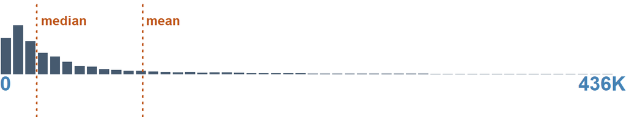

**PREVIEW**:

```
2174 · 5261 · 8602 · 14033 · 3086 · 4859 · 6625 · 6873 · 9260 · 10889 · 12089 · 13022 · 738
744 · 773 · 1837 · 2592 · 3360 · 5548 · 5588 · 5712 · 5927 · 5985 · 6022 · 6389 · 6683 · 6899
```

**STATS**:

| MIN | Q05 | Q25 | Q50 | MEAN | Q75 | Q95 | MAX |
| --- | --- | --- | --- | --- | --- | --- | --- |
| 43 | 2,807 | 10,983 | 25,594.5 | 99,510.78 | 66,666.5 | 429,838.7 | 10,125,014 |

number

Earnings by place of work

`earn_total`

Earnings by place of work

| ROWS | DISTINCT | MISSING/NA |
| --- | --- | --- |
| 78,600 | 76,636 (97.5%) | 2 (0.0%) |

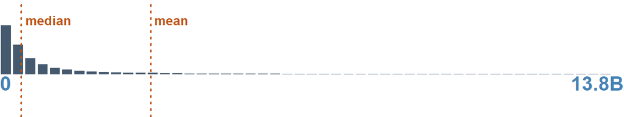

**PREVIEW**:

```
72744000 · 77073000 · 121650000 · 133801000 · 134364000 · 18293000 · 21554000 · 26730000
42265000 · 47494000 · 56715000 · 61887000 · 65160000 · 69043000 · 70384000 · 74288000 · 83562000
```

**STATS**:

| MIN | Q05 | Q25 | Q50 | MEAN | Q75 | Q95 | MAX |
| --- | --- | --- | --- | --- | --- | --- | --- |
| 916,000 | 53,336,850 | 179,595,250 | 471,066,000 | 3,349,613,591 | 1,468,838,500 | 13,618,953,900 | 576,683,756,000 |

number · measurement

Wages and salaries

`wages_total`

Wages and salaries

| ROWS | DISTINCT | MISSING/NA |
| --- | --- | --- |
| 78,600 | 75,553 (96.1%) | 2 (0.0%) |

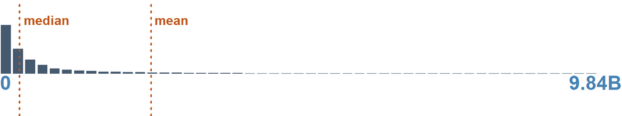

**PREVIEW**:

```
26705000 · 19836000 · 51620000 · 65272000 · 66719000 · 73983000 · 99204000 · 8132000 · 8664000
11481000 · 12357000 · 15723000 · 20037000 · 21885000 · 21995000 · 22898000 · 24966000 · 27538000
```

**STATS**:

| MIN | Q05 | Q25 | Q50 | MEAN | Q75 | Q95 | MAX |
| --- | --- | --- | --- | --- | --- | --- | --- |
| 537,000 | 27,831,950 | 109,853,750 | 309,715,000 | 2,395,433,650 | 1,016,982,250 | 9,674,221,400 | 426,589,834,000 |

number

Earnings: government and government enterprises

`gov_earn_total`

Earnings: government and government enterprises

| ROWS | DISTINCT | MISSING/NA |
| --- | --- | --- |
| 78,600 | 69,478 (88.4%) | 2 (0.0%) |

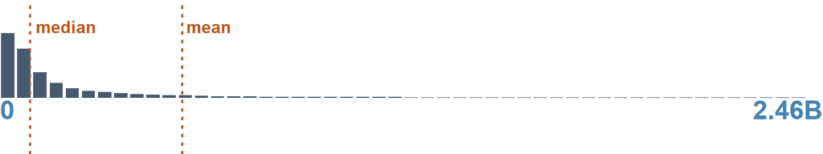

**PREVIEW**:

```
26663000 · 15327000 · 16829000 · 18729000 · 21203000 · 21561000 · 22965000 · 25934000 · 26918000
30417000 · 31154000 · 3006000 · 5788000 · 5926000 · 6697000 · 7344000 · 11087000 · 11812000
```

**STATS**:

| MIN | Q05 | Q25 | Q50 | MEAN | Q75 | Q95 | MAX |
| --- | --- | --- | --- | --- | --- | --- | --- |
| 366,746.6 | 11,684,400 | 37,779,750 | 90,245,500 | 545,961,144 | 283,766,500 | 2,426,715,700 | 85,264,444,000 |

number · measurement

Earnings: federal civilian government

`gov_earn_federal_civ`

Earnings: federal civilian government

| ROWS | DISTINCT | MISSING/NA | ZERO |
| --- | --- | --- | --- |
| 78,600 | 35,880 (45.6%) | 2 (0.0%) | 20 (0.0%) |

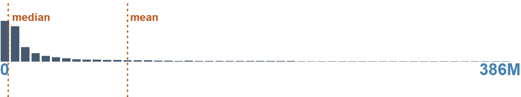

**PREVIEW**:

```
0 · 1879000 · 1696000 · 997000 · 1969000 · 3094000 · 1563000 · 1623000 · 1674000 · 1971000
2244000 · 2309000 · 2402000 · 2409000 · 1286000 · 1436000 · 1439000 · 1498000 · 1534000
```

**STATS**:

| MIN | Q05 | Q25 | Q50 | MEAN | Q75 | Q95 | MAX |
| --- | --- | --- | --- | --- | --- | --- | --- |
| 0 | 901,000 | 2,690,250 | 6,248,500 | 94,514,199 | 22,533,750 | 379,080,600 | 39,621,837,000 |

number · measurement

Earnings: military

`gov_earn_military`

Earnings: military

| ROWS | DISTINCT | MISSING/NA |
| --- | --- | --- |
| 78,600 | 24,564 (31.3%) | 2 (0.0%) |

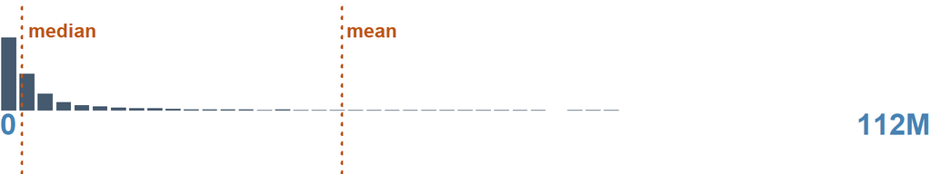

**PREVIEW**:

```
446000 · 394000 · 488000 · 986000 · 306000 · 314000 · 357000 · 361000 · 414000 · 515000 · 960000
1250000 · 354000 · 492000 · 893000 · 1147000 · 1261000 · 1395000 · 369000 · 405000 · 465000
```

**STATS**:

| MIN | Q05 | Q25 | Q50 | MEAN | Q75 | Q95 | MAX |
| --- | --- | --- | --- | --- | --- | --- | --- |
| 2,000 | 299,000 | 1,125,250 | 2,669,000 | 41,030,077 | 7,519,000 | 109,760,300 | 10,701,098,000 |

number

Earnings: state and local government

`gov_earn_sl`

Earnings: state and local government

| ROWS | DISTINCT | MISSING/NA |
| --- | --- | --- |
| 78,600 | 68,359 (87.0%) | 2 (0.0%) |

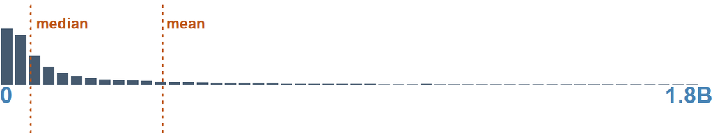

**PREVIEW**:

```
13823000 · 16424000 · 20197000 · 27269000 · 27310000 · 28882000 · 39191000 · 2266000 · 4481000
10672000 · 13585000 · 13716000 · 14460000 · 16845000 · 17466000 · 18038000 · 18173000 · 20058000
```

**STATS**:

| MIN | Q05 | Q25 | Q50 | MEAN | Q75 | Q95 | MAX |
| --- | --- | --- | --- | --- | --- | --- | --- |
| 306,429.4 | 9,493,700 | 32,240,500 | 78,256,000 | 410,416,868 | 231,147,500 | 1,771,659,050 | 76,231,139,000 |

number

Total employment

`emp_total`

Total employment (jobs)

| ROWS | DISTINCT | MISSING/NA |
| --- | --- | --- |
| 78,600 | 40,616 (51.7%) | 6,290 (8.0%) |

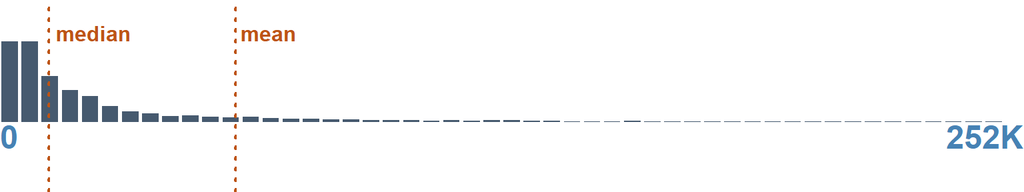

**PREVIEW**:

```
2583 · 2837 · 2927 · 3835 · 4692 · 1841 · 3087 · 3528 · 3532 · 4601 · 4841 · 5391 · 6692 · 456
1134 · 1438 · 1576 · 1672 · 1680 · 1696 · 1757 · 1947 · 1956 · 2140 · 2228 · 2248 · 2325 · 2616
```

**STATS**:

| MIN | Q05 | Q25 | Q50 | MEAN | Q75 | Q95 | MAX |
| --- | --- | --- | --- | --- | --- | --- | --- |
| 45.31 | 1,622.45 | 5,024 | 12,084.5 | 58,089.41 | 33,450 | 249,017.4 | 6,805,191 |

number · measurement

Employment: government and government enterprises

`gov_emp_total`

Employment: government and government enterprises

| ROWS | DISTINCT | MISSING/NA |
| --- | --- | --- |
| 78,600 | 19,208 (24.4%) | 6,290 (8.0%) |

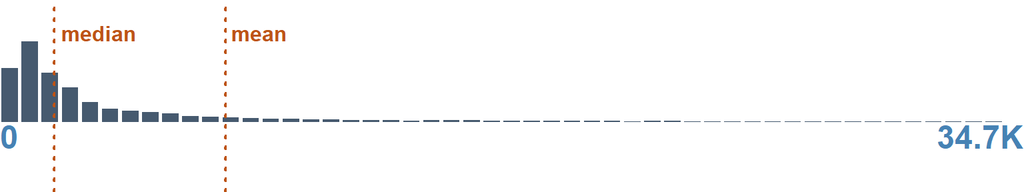

**PREVIEW**:

```
373 · 1090 · 398 · 430 · 499 · 763 · 709 · 736 · 754 · 197 · 564 · 757 · 401 · 412 · 459 · 469
558 · 649 · 741 · 792 · 987 · 360 · 565 · 644 · 681 · 762 · 799 · 899 · 903 · 908 · 948 · 958
```

**STATS**:

| MIN | Q05 | Q25 | Q50 | MEAN | Q75 | Q95 | MAX |
| --- | --- | --- | --- | --- | --- | --- | --- |
| 4.62 | 282 | 845 | 1,838 | 7,663.57 | 5,119 | 34,300.75 | 637,075 |

number · measurement

Employment: state and local government

`gov_emp_sl`

Employment: state and local government

| ROWS | DISTINCT | MISSING/NA |
| --- | --- | --- |
| 78,600 | 17,620 (22.4%) | 6,290 (8.0%) |

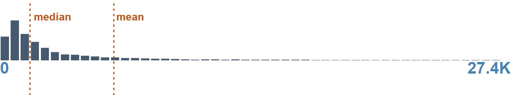

**PREVIEW**:

```
605 · 615 · 613 · 566 · 606 · 579 · 359 · 461 · 715 · 305 · 620 · 248 · 601 · 602 · 634 · 439
462 · 611 · 617 · 434 · 468 · 633 · 370 · 487 · 564 · 573 · 583 · 586 · 593 · 600 · 638 · 710
```

**STATS**:

| MIN | Q05 | Q25 | Q50 | MEAN | Q75 | Q95 | MAX |
| --- | --- | --- | --- | --- | --- | --- | --- |
| 3.67 | 239 | 736 | 1,622 | 6,114.45 | 4,313 | 27,100.4 | 561,636 |

number · measurement

Real GDP

`gdp_real`

Real GDP (chained 2017 dollars)

| ROWS | DISTINCT | MISSING/NA |
| --- | --- | --- |
| 78,600 | 74,487 (94.8%) | 3,145 (4.0%) |

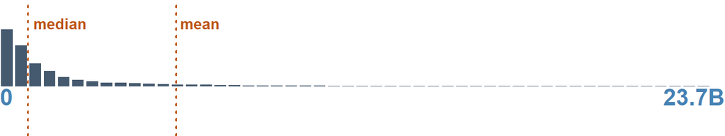

**PREVIEW**:

```
144009000 · 169737000 · 177633000 · 183215000 · 214779000 · 226987000 · 240255000 · 242888000
261506000 · 268342000 · 335869000 · 345701000 · 576198000 · 22389000 · 42245000 · 42639000
```

**STATS**:

| MIN | Q05 | Q25 | Q50 | MEAN | Q75 | Q95 | MAX |
| --- | --- | --- | --- | --- | --- | --- | --- |
| 4,131,910 | 109,083,800 | 357,429,000 | 926,642,000 | 5,773,088,609 | 2,728,918,000 | 23,371,128,000 | 813,692,135,000 |

number · measurement

Current-dollar GDP

`gdp_nominal`

Current-dollar GDP

| ROWS | DISTINCT | MISSING/NA |
| --- | --- | --- |
| 78,600 | 74,452 (94.7%) | 3,145 (4.0%) |

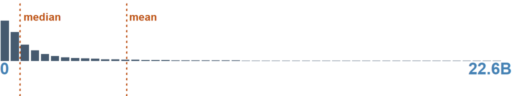

**PREVIEW**:

```
101002000 · 128954000 · 148757000 · 186417000 · 315549000 · 342178000 · 344843000 · 363086000
458834000 · 519352000 · 577331000 · 584623000 · 1192010000 · 11674000 · 19894000 · 26368000
```

**STATS**:

| MIN | Q05 | Q25 | Q50 | MEAN | Q75 | Q95 | MAX |
| --- | --- | --- | --- | --- | --- | --- | --- |
| 3,974,775 | 102,580,200 | 338,133,500 | 881,410,000 | 5,589,552,196 | 2,629,804,500 | 22,220,846,000 | 1.006673e+12 |

number · measurement

Personal current transfer receipts

`tr_total`

Personal current transfer receipts. Gap-filled: interpolated between observed years; see also tr_total_obs, _lin and _locf.

| ROWS | DISTINCT | MISSING/NA |
| --- | --- | --- |
| 78,600 | 68,563 (87.2%) | 2 (0.0%) |

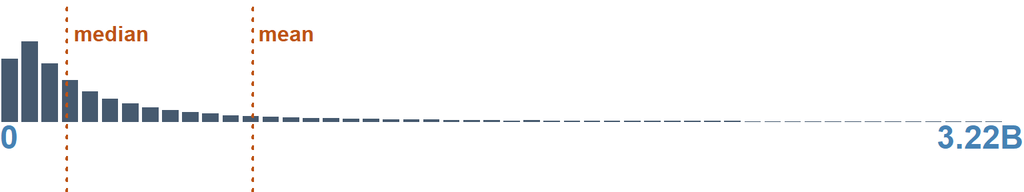

**PREVIEW**:

```
34745000 · 115084000 · 164418000 · 253884000 · 316188000 · 439231000 · 523387000 · 60311000
66868000 · 80548000 · 90647000 · 94290000 · 94569000 · 99096000 · 103650000 · 144363000
```

**STATS**:

| MIN | Q05 | Q25 | Q50 | MEAN | Q75 | Q95 | MAX |
| --- | --- | --- | --- | --- | --- | --- | --- |
| 228,000 | 21,776,350 | 87,347,250 | 210,759,500 | 796,750,019 | 547,026,051 | 3,179,709,350 | 167,179,724,000 |

number

Transfer receipts of individuals from governments

`tr_gov`

Transfer receipts of individuals from governments. Gap-filled: interpolated between observed years; see also tr_gov_obs, _lin and _locf.

| ROWS | DISTINCT | MISSING/NA |
| --- | --- | --- |
| 78,600 | 68,540 (87.2%) | 2 (0.0%) |

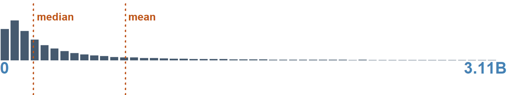

**PREVIEW**:

```
177395000 · 36686000 · 64171000 · 70123000 · 147663000 · 188597000 · 207028000 · 22037000
27140000 · 38454000 · 54410000 · 56548000 · 86439000 · 90486000 · 95933000 · 96168000
```

**STATS**:

| MIN | Q05 | Q25 | Q50 | MEAN | Q75 | Q95 | MAX |
| --- | --- | --- | --- | --- | --- | --- | --- |
| 215,000 | 21,051,850 | 84,677,766 | 204,739,000 | 771,480,394 | 530,416,750 | 3,072,368,850 | 162,692,299,000 |

number

Social Security benefits

`tr_socsec`

Social Security benefits. Gap-filled: interpolated between observed years; see also tr_socsec_obs, _lin and _locf.

| ROWS | DISTINCT | MISSING/NA |
| --- | --- | --- |
| 78,600 | 62,234 (79.2%) | 2 (0.0%) |

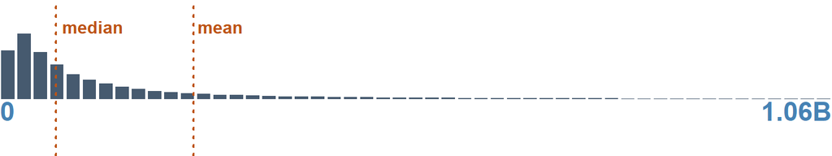

**PREVIEW**:

```
14869000 · 18023000 · 8750000 · 15148000 · 23466000 · 29674000 · 49856000 · 63839000 · 73993000
159091000 · 7703000 · 9998000 · 11517000 · 11843000 · 12528000 · 14844000 · 16580000 · 16766000
```

**STATS**:

| MIN | Q05 | Q25 | Q50 | MEAN | Q75 | Q95 | MAX |
| --- | --- | --- | --- | --- | --- | --- | --- |
| 128,000 | 7,673,850 | 29,923,750 | 71,968,000 | 247,445,482 | 185,994,000 | 1,050,260,000 | 24,877,690,000 |

number

Medical benefits

`tr_medical`

Medical benefits (Medicare + Medicaid + military). Gap-filled: interpolated between observed years; see also tr_medical_obs, _lin and _locf.

| ROWS | DISTINCT | MISSING/NA |
| --- | --- | --- |
| 78,600 | 64,122 (81.6%) | 2 (0.0%) |

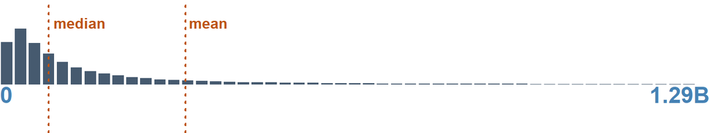

**PREVIEW**:

```
15092000 · 45943000 · 105996000 · 16873000 · 32355000 · 38911000 · 48697000 · 51849000
65132000 · 89423000 · 93540000 · 105133000 · 190477000 · 4499000 · 4947000 · 6234000 · 6423000
```

**STATS**:

| MIN | Q05 | Q25 | Q50 | MEAN | Q75 | Q95 | MAX |
| --- | --- | --- | --- | --- | --- | --- | --- |
| 32,000 | 8,922,357 | 36,835,000 | 88,424,000 | 337,280,707 | 224,715,000 | 1,275,442,700 | 75,013,413,000 |

number

Medicare benefits

`tr_medicare`

Medicare benefits. Gap-filled: interpolated between observed years; see also tr_medicare_obs, _lin and _locf.

| ROWS | DISTINCT | MISSING/NA |
| --- | --- | --- |
| 78,600 | 58,700 (74.7%) | 2 (0.0%) |

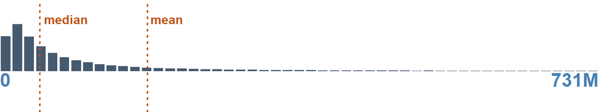

**PREVIEW**:

```
16485000 · 20608000 · 27719000 · 36686000 · 13457000 · 13632000 · 14272000 · 14940000 · 18592000
21322000 · 24713000 · 30341000 · 38197000 · 2805000 · 3436000 · 4237000 · 5383000 · 5563000
```

**STATS**:

| MIN | Q05 | Q25 | Q50 | MEAN | Q75 | Q95 | MAX |
| --- | --- | --- | --- | --- | --- | --- | --- |
| 31,000 | 5,290,000 | 20,414,000 | 48,905,500 | 180,313,532 | 124,972,750 | 722,431,400 | 29,402,585,000 |

number · measurement

Public assistance medical care

`tr_medicaid`

Public assistance medical care (mostly Medicaid). Gap-filled: interpolated between observed years; see also tr_medicaid_obs, _lin and _locf.

| ROWS | DISTINCT | MISSING/NA | ZERO |
| --- | --- | --- | --- |
| 78,600 | 55,383 (70.5%) | 2 (0.0%) | 10 (0.0%) |

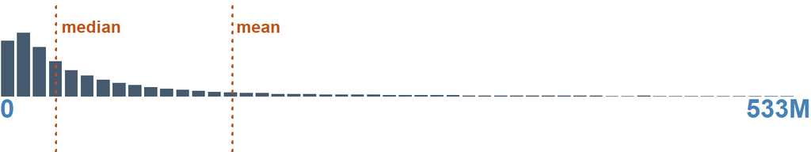

**PREVIEW**:

```
0 · 20270000 · 1266000 · 13165000 · 28322000 · 197000 · 5086000 · 10091000 · 16238000 · 44279000
218000 · 390000 · 1439000 · 1916000 · 3451000 · 4721000 · 5710000 · 6202000 · 6776000 · 6785000
```

**STATS**:

| MIN | Q05 | Q25 | Q50 | MEAN | Q75 | Q95 | MAX |
| --- | --- | --- | --- | --- | --- | --- | --- |
| 0 | 2,792,850 | 14,833,750 | 36,833,500 | 153,040,077 | 93,886,000 | 525,730,250 | 45,513,727,000 |

number · measurement

Income maintenance

`tr_income_maint`

Income maintenance (SSI, EITC, SNAP, other). Gap-filled: interpolated between observed years; see also tr_income_maint_obs, _lin and _locf.

| ROWS | DISTINCT | MISSING/NA |
| --- | --- | --- |
| 78,600 | 46,156 (58.7%) | 2 (0.0%) |

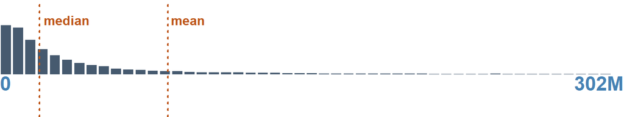

**PREVIEW**:

```
1215000 · 3793000 · 1916000 · 2013000 · 4790000 · 636000 · 1169000 · 1542000 · 2153000 · 2510000
3045000 · 749000 · 966000 · 1252000 · 1293000 · 1754000 · 1972000 · 2196000 · 2299000 · 2413000
```

**STATS**:

| MIN | Q05 | Q25 | Q50 | MEAN | Q75 | Q95 | MAX |
| --- | --- | --- | --- | --- | --- | --- | --- |
| 2,000 | 1,335,850 | 7,282,000 | 19,205,500 | 81,362,414 | 49,425,500 | 297,715,850 | 23,303,277,000 |

number · measurement

SNAP benefits

`tr_snap`

SNAP benefits. Gap-filled: interpolated between observed years; see also tr_snap_obs, _lin and _locf.

| ROWS | DISTINCT | MISSING/NA | ZERO |
| --- | --- | --- | --- |
| 78,600 | 26,668 (33.9%) | 2 (0.0%) | 23 (0.0%) |

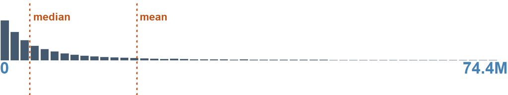

**PREVIEW**:

```
111000 · 242000 · 44000 · 182000 · 194000 · 45000 · 46000 · 109000 · 69000 · 40000 · 81000
87000 · 133000 · 173000 · 211000 · 43000 · 49000 · 86000 · 94000 · 212000 · 33000 · 36000
```

**STATS**:

| MIN | Q05 | Q25 | Q50 | MEAN | Q75 | Q95 | MAX |
| --- | --- | --- | --- | --- | --- | --- | --- |
| 0 | 187,000 | 1,425,000 | 4,367,394 | 20,091,694 | 12,356,750 | 73,137,331 | 6,058,261,000 |

number · measurement

Unemployment insurance compensation

`tr_unemp`

Unemployment insurance compensation. Gap-filled: interpolated between observed years; see also tr_unemp_obs, _lin and _locf.

| ROWS | DISTINCT | MISSING/NA | ZERO |
| --- | --- | --- | --- |
| 78,600 | 26,342 (33.5%) | 2 (0.0%) | 3 (0.0%) |

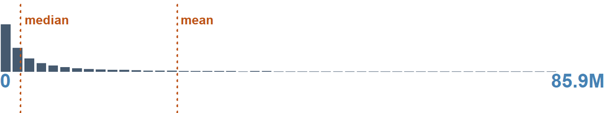

**PREVIEW**:

```
247000 · 152000 · 77000 · 101000 · 246000 · 80000 · 117000 · 133000 · 155000 · 260000 · 160000
91000 · 99000 · 109000 · 151000 · 162000 · 209000 · 254000 · 299000 · 63000 · 119000 · 121000
```

**STATS**:

| MIN | Q05 | Q25 | Q50 | MEAN | Q75 | Q95 | MAX |
| --- | --- | --- | --- | --- | --- | --- | --- |
| 0 | 166,000 | 941,000 | 2,949,000 | 25,215,782 | 9,845,000 | 84,410,127 | 31,040,534,000 |

number

Veterans' benefits

`tr_veterans`

Veterans' benefits. Gap-filled: interpolated between observed years; see also tr_veterans_obs, _lin and _locf.

| ROWS | DISTINCT | MISSING/NA |
| --- | --- | --- |
| 78,600 | 31,724 (40.4%) | 2 (0.0%) |

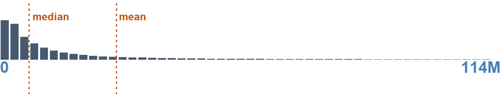

**PREVIEW**:

```
828000 · 1043000 · 1291000 · 724000 · 935000 · 1392000 · 1558000 · 636000 · 982000 · 1298000
1401000 · 1543000 · 1835000 · 366000 · 447000 · 668000 · 738000 · 1015000 · 1223000 · 1359000
```

**STATS**:

| MIN | Q05 | Q25 | Q50 | MEAN | Q75 | Q95 | MAX |
| --- | --- | --- | --- | --- | --- | --- | --- |
| 6,000 | 510,000 | 2,432,000 | 6,594,000 | 26,431,538 | 19,207,500 | 111,908,700 | 2,667,814,000 |

number · measurement

Education and training assistance

`tr_education`

Education and training assistance. Gap-filled: interpolated between observed years; see also tr_education_obs, _lin and _locf.

| ROWS | DISTINCT | MISSING/NA |
| --- | --- | --- |
| 78,600 | 25,624 (32.6%) | 2 (0.0%) |

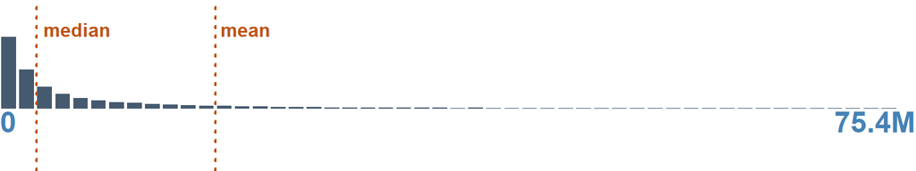

**PREVIEW**:

```
93000 · 152000 · 156000 · 70000 · 158000 · 99000 · 108000 · 177000 · 153000 · 176000 · 112000
147000 · 62000 · 86000 · 165000 · 80000 · 135000 · 140000 · 157000 · 169000 · 179000 · 128000
```

**STATS**:

| MIN | Q05 | Q25 | Q50 | MEAN | Q75 | Q95 | MAX |
| --- | --- | --- | --- | --- | --- | --- | --- |
| 2,000 | 166,000 | 981,000 | 3,041,000 | 17,774,027 | 10,805,000 | 74,100,000 | 3,214,477,000 |

number · measurement

Transfer receipts of nonprofit institutions

`tr_nonprofit`

Transfer receipts of nonprofit institutions (descriptive only). Gap-filled: interpolated between observed years; see also tr_nonprofit_obs, _lin and _locf.

| ROWS | DISTINCT | MISSING/NA |
| --- | --- | --- |
| 78,600 | 24,467 (31.1%) | 2 (0.0%) |

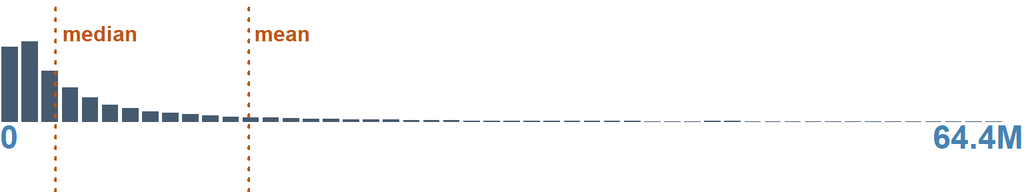

**PREVIEW**:

```
1010000 · 386000 · 671000 · 1541000 · 952000 · 1079000 · 198000 · 219000 · 563000 · 565000
944000 · 1147000 · 1930000 · 241000 · 391000 · 726000 · 779000 · 802000 · 814000 · 827000
```

**STATS**:

| MIN | Q05 | Q25 | Q50 | MEAN | Q75 | Q95 | MAX |
| --- | --- | --- | --- | --- | --- | --- | --- |
| 5,000 | 361,000 | 1,422,000 | 3,501,000 | 15,669,953 | 9,850,750 | 63,446,150 | 4,167,196,000 |

number

Total presidential votes cast

`votes_total`

Total presidential votes cast (all candidates)

| ROWS | DISTINCT | MISSING/NA |
| --- | --- | --- |
| 78,600 | 16,882 (21.5%) | 56,600 (72.0%) |

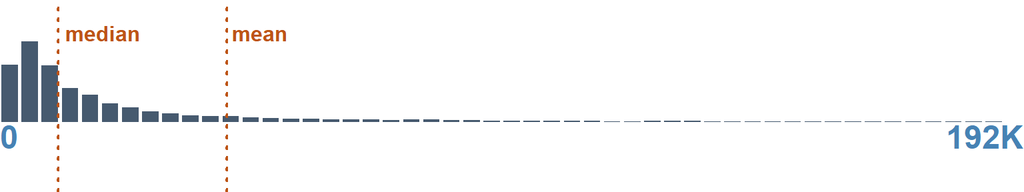

**PREVIEW**:

```
1017 · 3930 · 1110 · 3239 · 4058 · 928 · 935 · 1369 · 1381 · 1413 · 1494 · 1590 · 1759 · 1837
2006 · 2031 · 2102 · 2160 · 2178 · 2306 · 2602 · 2974 · 3225 · 3561 · 3576 · 3788 · 3826 · 3849
```

**STATS**:

| MIN | Q05 | Q25 | Q50 | MEAN | Q75 | Q95 | MAX |
| --- | --- | --- | --- | --- | --- | --- | --- |
| 64 | 1,368 | 4,860 | 10,930 | 42,615.18 | 29,096 | 189,971.1 | 4,263,443 |

number

Democratic presidential votes

`votes_dem`

Democratic presidential votes

| ROWS | DISTINCT | MISSING/NA |
| --- | --- | --- |
| 78,600 | 12,554 (16.0%) | 56,600 (72.0%) |

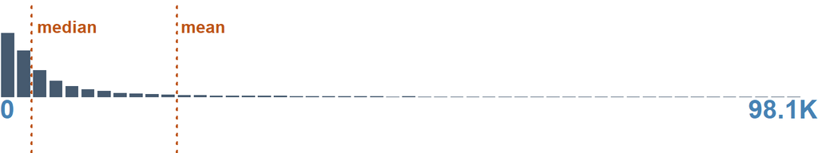

**PREVIEW**:

```
215 · 541 · 845 · 965 · 1241 · 1458 · 168 · 214 · 216 · 222 · 229 · 264 · 265 · 281 · 283 · 324
346 · 403 · 468 · 479 · 482 · 605 · 736 · 752 · 794 · 818 · 930 · 1048 · 1170 · 1910 · 3301
```

**STATS**:

| MIN | Q05 | Q25 | Q50 | MEAN | Q75 | Q95 | MAX |
| --- | --- | --- | --- | --- | --- | --- | --- |
| 4 | 283 | 1,444.75 | 3,786.5 | 21,233.19 | 10,928.25 | 96,448.5 | 3,028,885 |

number · measurement

Republican presidential votes

`votes_rep`

Republican presidential votes

| ROWS | DISTINCT | MISSING/NA |
| --- | --- | --- |
| 78,600 | 14,855 (18.9%) | 56,600 (72.0%) |

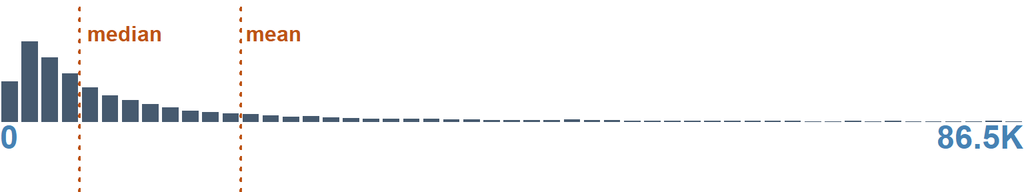

**PREVIEW**:

```
1794 · 1317 · 1487 · 1853 · 1936 · 2021 · 2557 · 2638 · 2721 · 2788 · 2998 · 3166 · 3968 · 5288
348 · 706 · 953 · 1056 · 1075 · 1132 · 1159 · 1178 · 1225 · 1330 · 1385 · 1466 · 1490 · 1496
```

**STATS**:

| MIN | Q05 | Q25 | Q50 | MEAN | Q75 | Q95 | MAX |
| --- | --- | --- | --- | --- | --- | --- | --- |
| 54 | 893 | 3,011 | 6,752.5 | 20,334.25 | 17,313.5 | 85,696.65 | 1,189,862 |

number · ratio

votes_dem / votes_total

`dem_share`

votes_dem / votes_total

| ROWS | DISTINCT | MISSING/NA |
| --- | --- | --- |
| 78,600 | 21,742 (27.7%) | 56,600 (72.0%) |

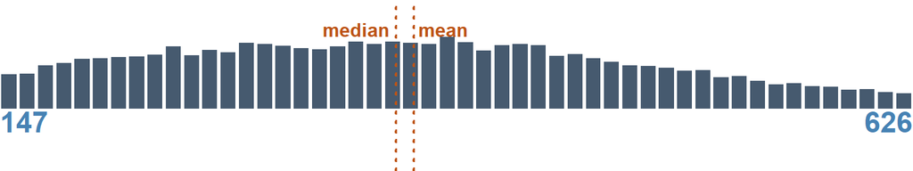

**PREVIEW**:

```
0.277 · 0.355 · 0.366 · 0.379 · 0.408 · 0.428 · 0.414 · 0.25 · 0.132 · 0.133 · 0.3 · 0.45
0.038 · 0.056 · 0.076 · 0.085 · 0.09 · 0.092 · 0.113 · 0.118
```

**STATS**:

| MIN | Q05 | Q25 | Q50 | MEAN | Q75 | Q95 | MAX |
| --- | --- | --- | --- | --- | --- | --- | --- |
| 0.03 | 0.15 | 0.25 | 0.36 | 0.36 | 0.46 | 0.63 | 0.93 |

number · ratio

votes_rep / votes_total

`rep_share`

votes_rep / votes_total

| ROWS | DISTINCT | MISSING/NA |
| --- | --- | --- |
| 78,600 | 21,744 (27.7%) | 56,600 (72.0%) |

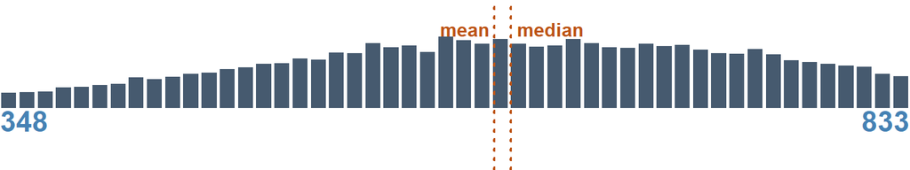

**PREVIEW**:

```
0.513 · 0.528 · 0.545 · 0.548 · 0.586 · 0.594 · 0.611 · 0.769 · 0.6 · 0.826 · 0.333 · 0.44
0.444 · 0.48 · 0.5 · 0.555 · 0.567 · 0.57 · 0.591 · 0.605 · 0.625 · 0.643
```

**STATS**:

| MIN | Q05 | Q25 | Q50 | MEAN | Q75 | Q95 | MAX |
| --- | --- | --- | --- | --- | --- | --- | --- |
| 0.04 | 0.35 | 0.52 | 0.62 | 0.61 | 0.72 | 0.83 | 0.96 |

number · ratio

(votes_dem - votes_rep) / votes_total

`dem_margin`

(votes_dem - votes_rep) / votes_total. Gap-filled: interpolated between observed years; see also dem_margin_obs, _lin and _locf.

| ROWS | DISTINCT | MISSING/NA |
| --- | --- | --- |
| 78,600 | 77,897 (99.1%) | 29 (0.0%) |

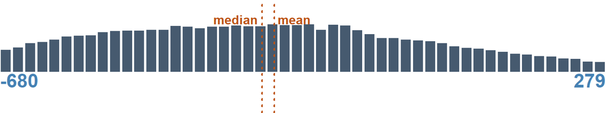

**PREVIEW**:

```
-0.124 · -0.116 · -0.283 · -0.131 · -0.296 · -0.269 · -0.178 · -0.108 · -0.235 · -0.145 · -0.159
-0.136 · -0.31 · -0.225 · -0.245 · -0.255 · -0.147 · -0.14
```

**STATS**:

| MIN | Q05 | Q25 | Q50 | MEAN | Q75 | Q95 | MAX |
| --- | --- | --- | --- | --- | --- | --- | --- |
| -0.93 | -0.68 | -0.47 | -0.27 | -0.25 | -0.06 | 0.28 | 0.87 |

number · ratio

1 - |dem_margin|

`competitiveness`

1 - |dem_margin|

| ROWS | DISTINCT | MISSING/NA |
| --- | --- | --- |
| 78,600 | 21,753 (27.7%) | 56,600 (72.0%) |

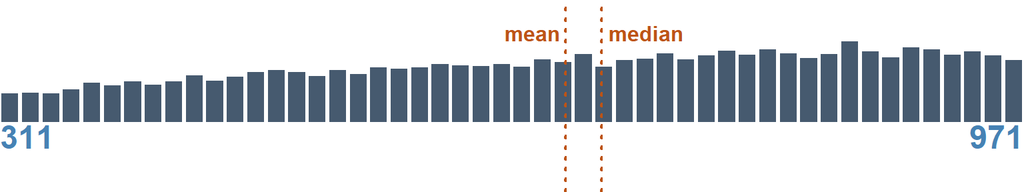

**PREVIEW**:

```
0.69 · 0.745 · 0.785 · 0.853 · 0.86 · 0.869 · 0.899 · 0.333 · 0.286 · 0.167 · 0.196 · 0.226
0.245 · 0.282 · 0.304 · 0.317 · 0.332 · 0.34 · 0.373 · 0.395
```

**STATS**:

| MIN | Q05 | Q25 | Q50 | MEAN | Q75 | Q95 | MAX |
| --- | --- | --- | --- | --- | --- | --- | --- |
| 0.07 | 0.31 | 0.52 | 0.7 | 0.68 | 0.85 | 0.97 | 1 |

number

QCEW federal government employment

`qcew_fgov_emp`

QCEW federal government employment (annual average, place of work)

| ROWS | DISTINCT | MISSING/NA | ZERO |
| --- | --- | --- | --- |
| 78,600 | 6,979 (8.9%) | 27 (0.0%) | 20 (0.0%) |

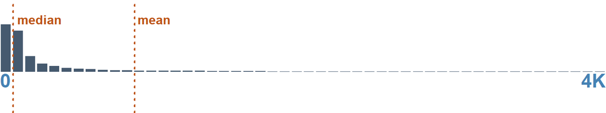

**PREVIEW**:

```
36 · 26 · 35 · 28 · 40 · 37 · 34 · 32 · 42 · 33 · 27 · 39 · 25 · 19 · 47 · 30 · 41 · 43 · 49
44 · 38 · 31 · 48 · 45 · 50 · 24 · 23 · 29 · 18 · 46 · 52 · 55 · 53 · 51 · 54 · 21 · 22 · 57
```

**STATS**:

| MIN | Q05 | Q25 | Q50 | MEAN | Q75 | Q95 | MAX |
| --- | --- | --- | --- | --- | --- | --- | --- |
| 0 | 15 | 42 | 86 | 888.73 | 267 | 3,977 | 212,311 |

number · measurement

QCEW state government employment

`qcew_sgov_emp`

QCEW state government employment

| ROWS | DISTINCT | MISSING/NA | ZERO |
| --- | --- | --- | --- |
| 78,600 | 16,827 (21.4%) | 27 (0.0%) | 5 (0.0%) |

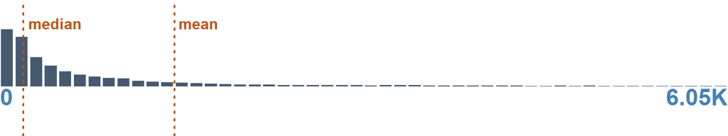

**PREVIEW**:

```
29 · 10 · 15 · 14 · 30 · 11 · 12 · 17 · 28 · 16 · 40 · 19 · 13 · 27 · 22 · 23 · 34 · 18 · 21
39 · 9 · 33 · 20 · 32 · 37 · 38 · 24 · 25 · 41 · 8 · 35 · 26 · 36 · 31 · 44 · 45 · 42 · 43 · 47
```

**STATS**:

| MIN | Q05 | Q25 | Q50 | MEAN | Q75 | Q95 | MAX |
| --- | --- | --- | --- | --- | --- | --- | --- |
| 0 | 14 | 54 | 196 | 1,452.88 | 792 | 6,048.6 | 118,823 |

number · measurement

QCEW local government employment

`qcew_lgov_emp`

QCEW local government employment (incl. public schools and hospitals)

| ROWS | DISTINCT | MISSING/NA |
| --- | --- | --- |
| 78,600 | 21,384 (27.2%) | 27 (0.0%) |

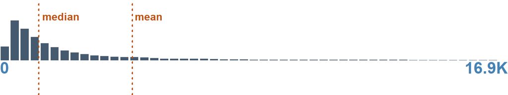

**PREVIEW**:

```
556 · 601 · 457 · 472 · 454 · 564 · 602 · 333 · 531 · 539 · 580 · 273 · 404 · 465 · 481 · 549
554 · 571 · 579 · 653 · 334 · 343 · 490 · 578 · 412 · 449 · 463 · 469 · 528 · 546 · 625 · 348
```

**STATS**:

| MIN | Q05 | Q25 | Q50 | MEAN | Q75 | Q95 | MAX |
| --- | --- | --- | --- | --- | --- | --- | --- |
| 0.06 | 207 | 602 | 1,286 | 4,397.4 | 3,118 | 16,711.8 | 465,665 |

number

QCEW federal government total annual wages

`qcew_fgov_wages`

QCEW federal government total annual wages ($)

| ROWS | DISTINCT | MISSING/NA | ZERO |
| --- | --- | --- | --- |
| 78,600 | 78,352 (99.7%) | 27 (0.0%) | 14 (0.0%) |

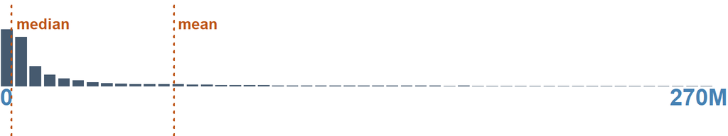

**PREVIEW**:

```
0 · 792564 · 1077270 · 75181 · 101496 · 188326 · 329634 · 331874 · 373505 · 382685 · 442822
447307 · 463370 · 474511 · 508757 · 534049 · 558044 · 589448 · 631801 · 636121 · 648198 · 658762
```

**STATS**:

| MIN | Q05 | Q25 | Q50 | MEAN | Q75 | Q95 | MAX |
| --- | --- | --- | --- | --- | --- | --- | --- |
| 0 | 595,550.2 | 1,808,528 | 4,222,001 | 64,663,474 | 15,325,473 | 265,296,209 | 27,067,241,499 |

number · measurement

QCEW state government wages

`qcew_sgov_wages`

QCEW state government wages ($)

| ROWS | DISTINCT | MISSING/NA | ZERO |
| --- | --- | --- | --- |
| 78,600 | 78,457 (99.8%) | 27 (0.0%) | 2 (0.0%) |

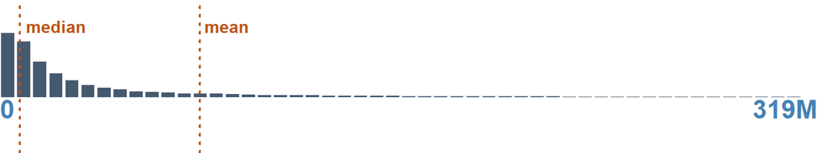

**PREVIEW**:

```
0 · 156610 · 179153.034 · 240781 · 261304 · 264818 · 283066 · 358108 · 397295 · 429072 · 435554
435844 · 445969 · 481288 · 481938 · 495124 · 512126 · 516255 · 522433 · 527602 · 559913 · 566049
```

**STATS**:

| MIN | Q05 | Q25 | Q50 | MEAN | Q75 | Q95 | MAX |
| --- | --- | --- | --- | --- | --- | --- | --- |
| 0 | 542,026 | 2,085,430 | 7,868,289 | 78,141,428 | 32,151,275 | 313,718,132 | 13,816,578,560 |

number

QCEW local government wages

`qcew_lgov_wages`

QCEW local government wages ($)

| ROWS | DISTINCT | MISSING/NA |
| --- | --- | --- |
| 78,600 | 78,558 (99.9%) | 27 (0.0%) |

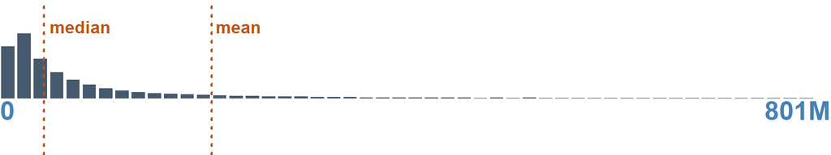

**PREVIEW**:

```
1123572.145 · 5842412.015 · 6997239 · 11922456 · 13831826 · 14658224 · 15605576 · 17103395
20988232 · 27602408 · 30539249 · 30981609 · 36543059 · 37066487 · 43748844 · 46680527 · 1099.206
```

**STATS**:

| MIN | Q05 | Q25 | Q50 | MEAN | Q75 | Q95 | MAX |
| --- | --- | --- | --- | --- | --- | --- | --- |
| 1,099.21 | 5,618,083 | 18,205,585 | 42,465,667 | 204,048,626 | 116,279,201 | 791,379,657 | 42,700,177,348 |

number

`qcew_sgov_imputed`

| ROWS | DISTINCT | MISSING/NA | ZERO |
| --- | --- | --- | --- |
| 78,600 | 11 (0.0%) | 27 (0.0%) | 69,624 (88.6%) |

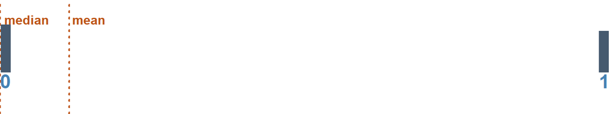

**PREVIEW**:

```
0 · 1 · 0.161 · 0.294 · 0.546 · 0.21 · 0.79 · 0.795 · 0.995 · 2
```

**STATS**:

| MIN | Q05 | Q25 | Q50 | MEAN | Q75 | Q95 | MAX |
| --- | --- | --- | --- | --- | --- | --- | --- |
| 0 | 0 | 0 | 0 | 0.11 | 0 | 1 | 2 |

number

`qcew_lgov_imputed`

Count of merged county-equivalents flagged (county flags summed; fractional where a county was split by population). County flag: 1 = suppressed county cell, imputed as state total minus disclosed counties, allocated by population: local

| ROWS | DISTINCT | MISSING/NA | ZERO |
| --- | --- | --- | --- |
| 78,600 | 12 (0.0%) | 27 (0.0%) | 71,160 (90.5%) |

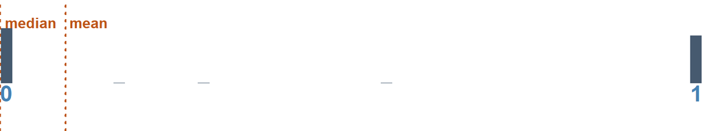

**PREVIEW**:

```
0 · 1 · 0.161 · 0.294 · 0.546 · 0.995 · 0.005 · 0.21 · 0.79 · 0.795 · 2
```

**STATS**:

| MIN | Q05 | Q25 | Q50 | MEAN | Q75 | Q95 | MAX |
| --- | --- | --- | --- | --- | --- | --- | --- |
| 0 | 0 | 0 | 0 | 0.09 | 0 | 1 | 2 |

number · measurement

ACS civilian employed residents 16+

`acs_cow_den`

ACS civilian employed residents 16+ (B24080 universe)

| ROWS | DISTINCT | MISSING/NA |
| --- | --- | --- |
| 78,600 | 30,368 (38.6%) | 28,296 (36.0%) |

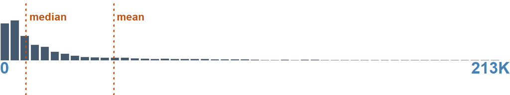

**PREVIEW**:

```
1128 · 2952 · 3840 · 4661 · 965 · 1023 · 1166 · 2048 · 2088 · 2115 · 2238 · 2440 · 2548 · 2600
2636 · 2882 · 2988 · 3618 · 4392 · 5177 · 7347 · 876 · 1129 · 1212 · 1359 · 1529 · 1616 · 1735
```

**STATS**:

| MIN | Q05 | Q25 | Q50 | MEAN | Q75 | Q95 | MAX |
| --- | --- | --- | --- | --- | --- | --- | --- |
| 25 | 1,239 | 4,548.75 | 10,846 | 47,662.52 | 29,728 | 209,893.5 | 4,929,863 |

number

ACS residents working for private not-for-profits

`acs_cow_npo`

ACS residents working for private not-for-profits

| ROWS | DISTINCT | MISSING/NA | ZERO |
| --- | --- | --- | --- |
| 78,600 | 10,906 (13.9%) | 28,296 (36.0%) | 87 (0.1%) |

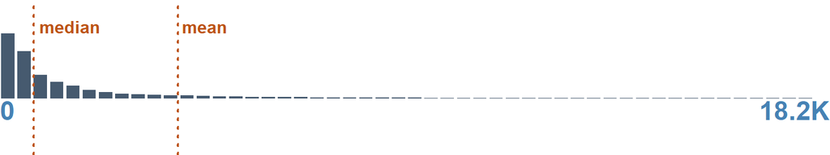

**PREVIEW**:

```
0 · 158 · 174 · 179 · 192 · 147 · 175 · 180 · 196 · 181 · 68 · 131 · 50 · 102 · 103 · 176 · 203
66 · 75 · 81 · 100 · 138 · 140 · 144 · 152 · 207 · 86 · 161 · 221 · 259 · 275 · 60 · 76 · 205
```

**STATS**:

| MIN | Q05 | Q25 | Q50 | MEAN | Q75 | Q95 | MAX |
| --- | --- | --- | --- | --- | --- | --- | --- |
| 0 | 66 | 279 | 734 | 3,889.1 | 2,367.25 | 17,855 | 378,483 |

number

ACS residents working for local government

`acs_cow_lgov`

ACS residents working for local government

| ROWS | DISTINCT | MISSING/NA | ZERO |
| --- | --- | --- | --- |
| 78,600 | 10,306 (13.1%) | 28,296 (36.0%) | 12 (0.0%) |

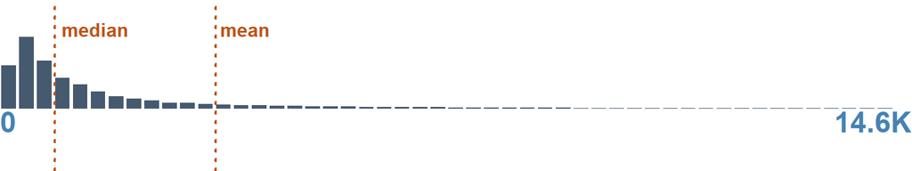

**PREVIEW**:

```
340 · 213 · 256 · 286 · 297 · 219 · 262 · 317 · 324 · 421 · 169 · 175 · 183 · 350 · 257 · 304
397 · 186 · 193 · 199 · 202 · 224 · 265 · 369 · 465 · 177 · 189 · 300 · 327 · 333 · 410 · 151
```

**STATS**:

| MIN | Q05 | Q25 | Q50 | MEAN | Q75 | Q95 | MAX |
| --- | --- | --- | --- | --- | --- | --- | --- |
| 0 | 132 | 396 | 886 | 3,464.06 | 2,319 | 14,459 | 388,826 |

number

ACS residents working for state government

`acs_cow_sgov`

ACS residents working for state government

| ROWS | DISTINCT | MISSING/NA | ZERO |
| --- | --- | --- | --- |
| 78,600 | 8,584 (10.9%) | 28,296 (36.0%) | 56 (0.1%) |

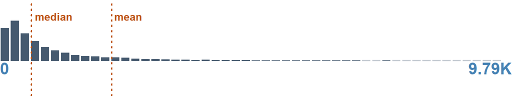

**PREVIEW**:

```
212 · 74 · 111 · 138 · 45 · 64 · 160 · 201 · 35 · 47 · 123 · 27 · 42 · 67 · 322 · 55 · 198 · 53
72 · 80 · 98 · 220 · 293 · 303 · 43 · 94 · 153 · 235 · 247 · 251 · 253 · 99 · 172 · 214 · 221
```

**STATS**:

| MIN | Q05 | Q25 | Q50 | MEAN | Q75 | Q95 | MAX |
| --- | --- | --- | --- | --- | --- | --- | --- |
| 0 | 51 | 249 | 600 | 2,137.82 | 1,614 | 9,650.85 | 159,830 |

number

ACS residents working for federal government

`acs_cow_fgov`

ACS residents working for federal government

| ROWS | DISTINCT | MISSING/NA | ZERO |
| --- | --- | --- | --- |
| 78,600 | 6,469 (8.2%) | 28,296 (36.0%) | 297 (0.4%) |

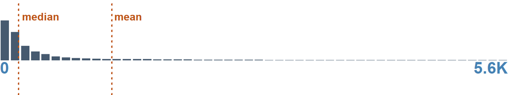

**PREVIEW**:

```
0 · 49 · 21 · 54 · 64 · 43 · 35 · 52 · 71 · 40 · 17 · 42 · 62 · 39 · 57 · 41 · 37 · 55 · 24 · 33
48 · 67 · 58 · 34 · 78 · 77 · 44 · 47 · 50 · 20 · 25 · 56 · 93 · 27 · 31 · 105 · 53 · 46 · 19
```

**STATS**:

| MIN | Q05 | Q25 | Q50 | MEAN | Q75 | Q95 | MAX |
| --- | --- | --- | --- | --- | --- | --- | --- |
| 0 | 19 | 83 | 205 | 1,233.31 | 641 | 5,587.85 | 83,166 |

number · measurement

Local current operations, excl. utilities and liquor stores

`cog_curop`

Local current operations, excl. utilities and liquor stores (E codes). Gap-filled: interpolated between observed years; see also cog_curop_obs, _lin and _locf.

| ROWS | DISTINCT | MISSING/NA |
| --- | --- | --- |
| 78,600 | 63,835 (81.2%) | 6,376 (8.1%) |

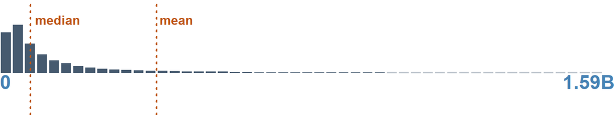

**PREVIEW**:

```
37067000 · 16170000 · 16948000 · 21375000 · 22907000 · 24362000 · 62018000 · 94188000
104710000 · 20374000 · 20907000 · 25645000 · 28812000 · 32811000 · 32922000 · 40179000
```

**STATS**:

| MIN | Q05 | Q25 | Q50 | MEAN | Q75 | Q95 | MAX |
| --- | --- | --- | --- | --- | --- | --- | --- |
| 92,000 | 11,402,760 | 34,691,950 | 79,724,200 | 405,505,152 | 218,353,250 | 1,571,437,200 | 81,292,206,000 |

number · measurement